# ProjectOne

# Basanta Khakurel

## 100 points

# DUE Sept 16 at Midnight

Below are the questions for the first data practical assignment. This project uses the “FossilAnts.csv” file, located in the data directory for the project. The point value of each question is denoted next to it. A blank cell is below each for your answer; feel free to create more blank cells as needed.

0. (5 pts) Create a directory called `projects`, and in it, a subdirectory called `project_one`. Use `download.files` to get [this file](https://github.com/BiologicalDataAnalysis2019/2021/blob/master/projects/project_one/ProjectOne.Rmd), and [this one](https://github.com/BiologicalDataAnalysis2019/2021/blob/master/projects/project_one/data/FossilAnts.csv).

```
download.file(url="https://raw.githubusercontent.com/BiologicalDataAnalysis2019/2022/main/projects/project_one/ProjectOne.Rmd", destfile = "C:/Users/basan/Desktop/Fall 2022/Biological_Data_Analysis/project_khakurel/project_one/ProjectOne.Rmd")

download.file(url="https://raw.githubusercontent.com/BiologicalDataAnalysis2019/2021/main/projects/project_one/data/FossilAnts.csv", destfile = "C:/Users/basan/Desktop/Fall 2022/Biological_Data_Analysis/project_khakurel/project_one/FossilAnts.csv")
```

1. 5 pts. Import the `tidyverse` package and load the data. The data for this part of the practical is located in the data directory. Save the data in a variable called `project_dat`. Print the data to the screen to ensure it loaded correctly.

```r
library(tidyverse)
project_dat <- read_csv("data/FossilAnts.csv")
project_dat
```

```
## # A tibble: 789 × 9
##    taxon                  refer…¹ subfa…² Tribe Genus Fossil min_ma max_ma Notes
##    <chr>                    <dbl> <chr>   <chr> <chr> <chr>   <dbl>  <dbl> <chr>
##  1 Agroecomyrmex_duisbur…   44414 Agroec… None  Agro… Yes     33.9    38   Note
##  2 Eulithomyrmex_rugosus     4971 Agroec… None  Euli… Yes     33.9    37.2 Note
##  3 Eulithomyrmex_striatus    4971 Agroec… None  Euli… Yes     33.9    37.2 Note
##  4 Ambyloponinae            59088 Ambylo… None  None  Yes     20.4    23.0 Note
##  5 Amblyoponini             53165 Ambylo… Ambl… Ambl… Yes     20.4    23.0 Note
##  6 Casaleia_eocenica        43781 Ambylo… None  Casa… Yes     40.4    48.6 Note
##  7 Casaleia_inversa         41286 Ambylo… None  Casa… Yes      5.33   16.0 Note
##  8 Casaleia_longiventris    37344 Ambylo… None  Casa… Yes     11.6    12.7 Note
##  9 Casaleia_orientalis      56094 Ambylo… None  Casa… Yes     33.9    38   Note
## 10 Myopopone_sinensis       16579 Ambylo… None  Myop… Yes     11.6    16.0 Note
## # … with 779 more rows, and abbreviated variable names ¹reference_no,
## #   ²subfamily
```

```r
#or
View(project_dat)
```

2. (5pts) Check the datatypes of each column. There is a column called reference number. This is a static identifier - it should not be changed, and is an indexer used to identify this specimen uniquely. Do we want to treat it as an integer (this is an opinion question - answers may vary).

```
In my opinion, this might not need to be changed because we will not be doing any mathematic operations in it. Those values are just reference values.
```

3. (5 pts) Change the datatype of the reference number column to character. Take a peek at the function as.character().

```r
?as.character
```

```
## starting httpd help server ... done
```

```r
project_dat %>%
  mutate(reference_no=as.character(project_dat$reference_no))
```

```
## # A tibble: 789 × 9
##    taxon                  refer…¹ subfa…² Tribe Genus Fossil min_ma max_ma Notes
##    <chr>                  <chr>   <chr>   <chr> <chr> <chr>   <dbl>  <dbl> <chr>
##  1 Agroecomyrmex_duisbur… 44414   Agroec… None  Agro… Yes     33.9    38   Note
##  2 Eulithomyrmex_rugosus  4971    Agroec… None  Euli… Yes     33.9    37.2 Note
##  3 Eulithomyrmex_striatus 4971    Agroec… None  Euli… Yes     33.9    37.2 Note
##  4 Ambyloponinae          59088   Ambylo… None  None  Yes     20.4    23.0 Note
##  5 Amblyoponini           53165   Ambylo… Ambl… Ambl… Yes     20.4    23.0 Note
##  6 Casaleia_eocenica      43781   Ambylo… None  Casa… Yes     40.4    48.6 Note
##  7 Casaleia_inversa       41286   Ambylo… None  Casa… Yes      5.33   16.0 Note
##  8 Casaleia_longiventris  37344   Ambylo… None  Casa… Yes     11.6    12.7 Note
##  9 Casaleia_orientalis    56094   Ambylo… None  Casa… Yes     33.9    38   Note
## 10 Myopopone_sinensis     16579   Ambylo… None  Myop… Yes     11.6    16.0 Note
## # … with 779 more rows, and abbreviated variable names ¹reference_no,
## #   ²subfamily
```

4. (5 pts) Look at your data. What are the missing data values? In particular, have a look at the `Tribe` column. In your opinion, are these intelligent missing values for the dataset? Why or why not? If not, how would you like to change them?

```
There are some missing values in the column 'Tribe'. The values are not the intelligent mising values and should be changed to NA. This could be done using na_if function from the tidyverse package.
```

6. (5 points) Are there any columns in your dataset that contain two pieces of data? If so, identify them.

```
The column 'taxon' has two pieces of data. They are the genus and species for the specific taxon. This could be separated to individual columns containing 'genus' and 'species'.
```

7. (5pts) Please look at the help page for the `separate` function.

```r
?separate
```

7. (10 pts) How could you separate one column into two?

```r
#creates a separate data.frame named 'taxon_separated'
taxon_separated <- project_dat %>%
separate(taxon, c("genus", "species"))
```

Next, we will test a hypothesis. Your hypthesis is that there are more specimens in the 75 million years ago (mya) - 100 mya interval than the 30 mya to the present interval.

8. (5 pts) Write out the steps you would take to address this question. Will you need to split up the data? Will you need to group the data based on the values in some column?

```
We would probably need to split the data to easily see the numbers of species from the interval 75 mya to 100 mya and 30 mya to present.
Using a pipe, we could filter out after_30 species containing species from 30 mya to present and see how many rows are in there.
And, we could again filter out before_75 species with the species from 75 mya to 100 mya and again get the number of rows.
Both the values can then be compared to address the question.
```

9. (15 pts) Perform the operations you described in (8).

```r
after_30 <- taxon_separated%>%
 filter(min_ma<30, max_ma<=30)%>%
 select(genus, species, min_ma, max_ma )

before_75 <- taxon_separated%>%
 filter(min_ma>=75, max_ma<=100)%>%
 select(genus,species, min_ma, max_ma)

view(after_30)
view(before_75)

new <- nrow(after_30)
old <- nrow(before_75)
print(paste("The number of species between 75mya to 100 mya is:", old))
```

```
## [1] "The number of species between 75mya to 100 mya is: 48"
```

```r
print(paste("The number of species between 30mya to present is:", new))
```

```
## [1] "The number of species between 30mya to present is: 313"
```

10. (5 pts) Do the results of your code support the hypothesis?

```
The results does not support the hypothesis. There are more speciments in the interval of 30mya to present than in the interval of 75 mya to 100 mya. The results show that there are 313 specimens in the recent interval (from 30mya to present) and 48 specimens in the older interval (from 75mya to 100 mya).
```

11. (10 pts) Save the dataframe with the split columns into a new directory called `project_one_data_output`. Save it as a csv file called “column_separated.csv”

```r
write_csv(taxon_separated, path = "/Users/basan/Desktop/Fall 2022/Biological_Data_Analysis/project_khakurel/project_one/project_one_data_output/column_separated.csv")
```

12. (10 pts) Produce a histogram of the number of specimens by minimum age. Look at the geom_histogram() help.

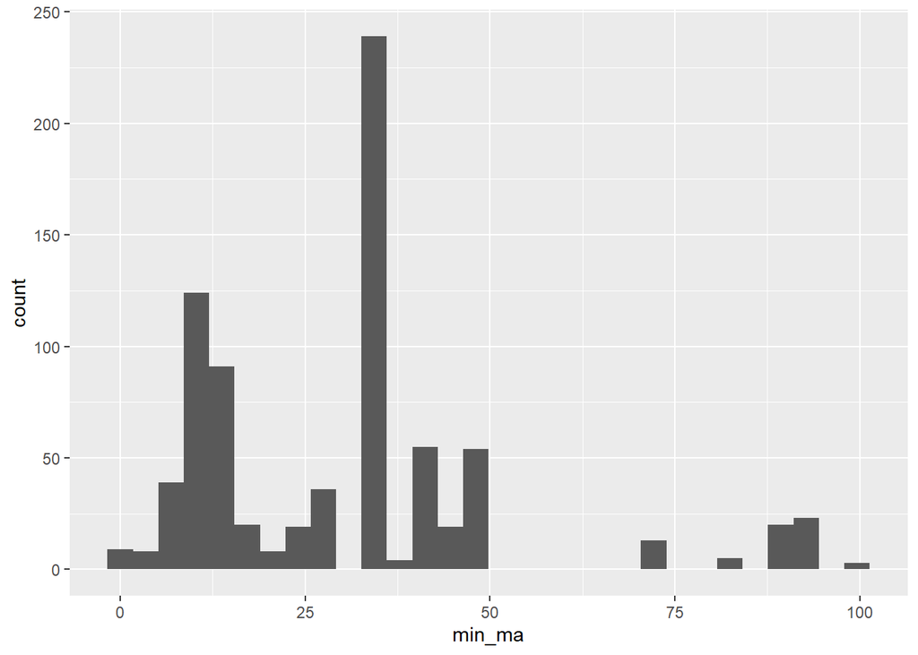

```r
plot <- ggplot(project_dat, mapping = aes(x=min_ma)) +
  geom_histogram()
plot
```

*** 13. (5 pts) Change the font size on your histogram so that it can be read comfortably on your computer screen from five feet away. Save the file as “large_font.pdf”.

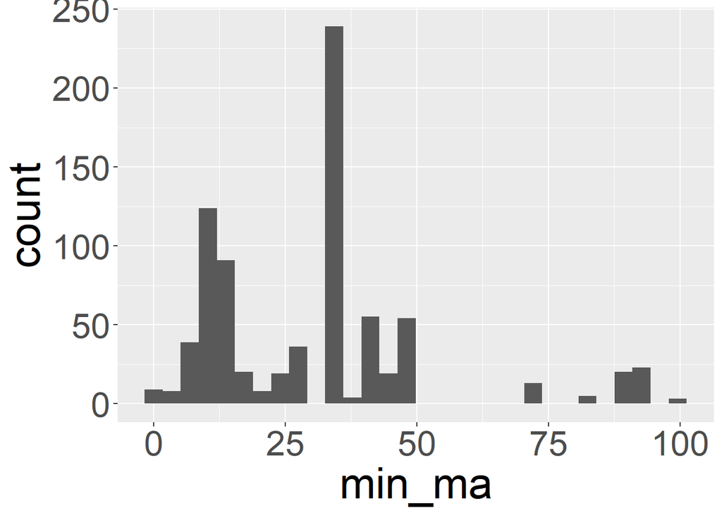

```r
plot_lg <- plot + theme(text=element_text(size=30))
ggsave("/Users/basan/Desktop/Fall 2022/Biological_Data_Analysis/project_khakurel/project_one/project_one_data_output/large_font.pdf", plot_lg)
plot_lg
```

*** 14. Finally, produce a histogram of counts for each subfamily.

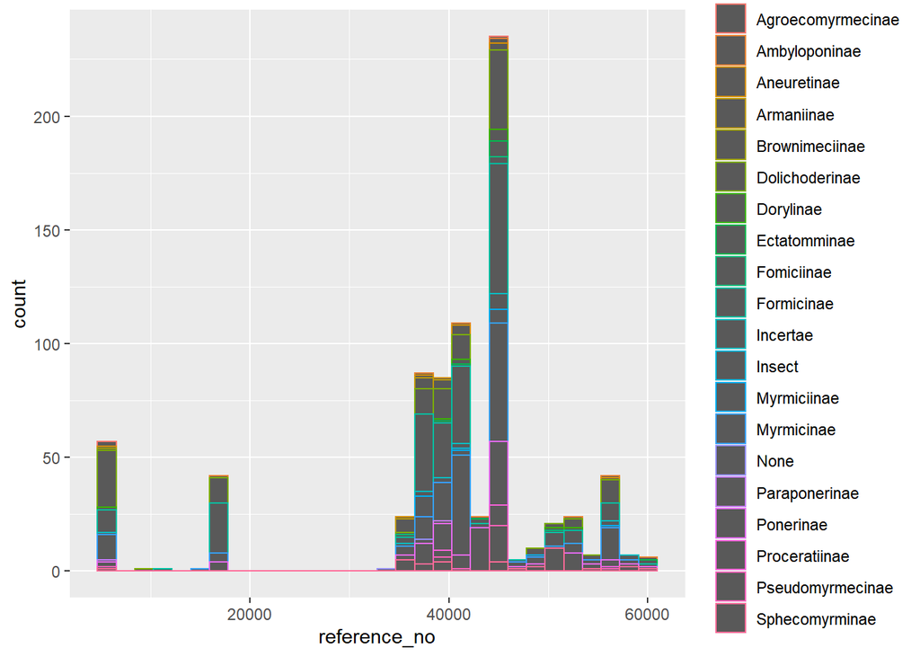

```r
plot_subfamily <- ggplot(project_dat, mapping = aes(reference_no,color=subfamily)) + geom_histogram()
plot_subfamily
```

___